# TO 414 Group Project 1

Shibi Sanjeev, Bryan Yu, Anthony Zhao, Ben Smith, Jackson Rocke

2/10/2021

Group Project 1: Due on 2/21 emails = bssmit tzhx rockej bryanyu

```r
library(tidyverse)
hotel_data = read.csv("hotel_bookings.csv")

hotel_data$arrival_date_year = as.factor(hotel_data$arrival_date_year)
hotel_data$arrival_date_month = as.factor(hotel_data$arrival_date_month)
hotel_data$arrival_date_week_number = as.factor(hotel_data$arrival_date_week_number)
hotel_data$arrival_date_day_of_month = as.factor(hotel_data$arrival_date_day_of_month)
```

**Basic Data Structure**

```r
#str(hotel_data)
```

### **Cancellations**

**Number of cancellations broken down by year and month**

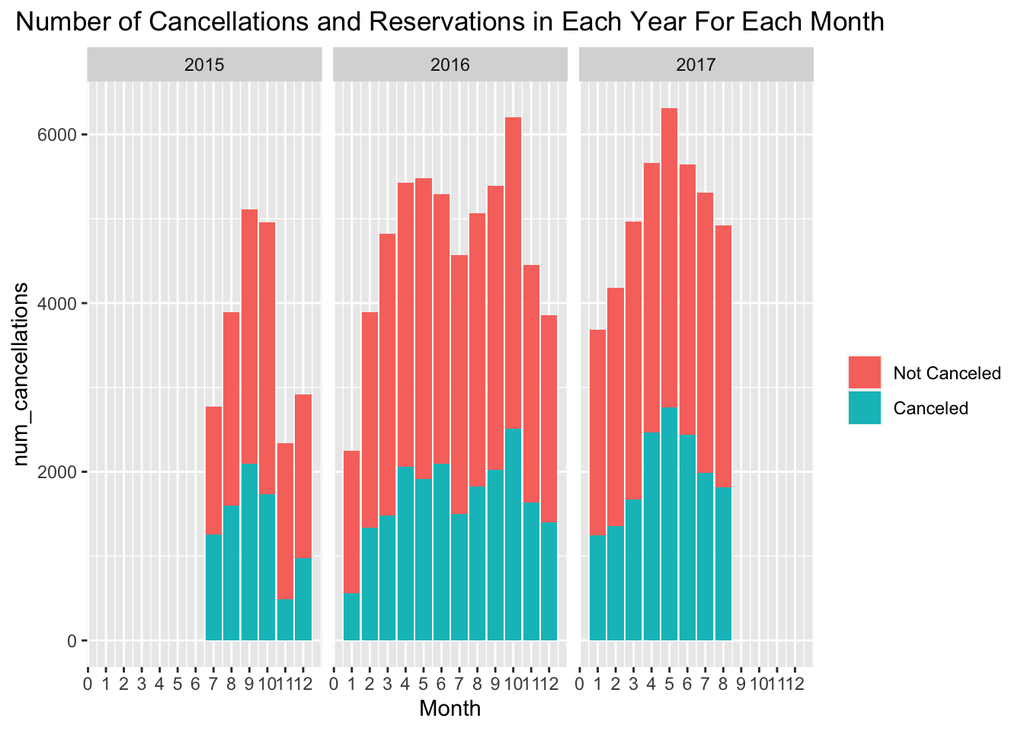

```r
#This new column month_num has the month of the arrival at the hotel, similar to the arrival_date_month column. However, this one is in numerical form. This helps us with graphing.
hotel_data$month_num = match(hotel_data$arrival_date_month, month.name)

#Number of cancellations broken down by year then month
num_cancellations_by_year_month = group_by(hotel_data, arrival_date_year, month_num, is_canceled) %>%
  summarize(num_cancellations = n())

ggplot(num_cancellations_by_year_month, aes(x = month_num, y = num_cancellations)) +
  geom_bar(aes(fill = as.factor(is_canceled)),stat = "identity") +
  facet_wrap(~arrival_date_year) +
  scale_x_continuous(name="Month", breaks = seq(0,12, 1)) +
  scale_fill_discrete(name = "", labels = c("Not Canceled", "Canceled")) +
  ggtitle("Number of Cancellations and Reservations in Each Year For Each Month") +
  theme(plot.title = element_text(hjust = 0.5))
```

**Number of reservations broken down by year and month but trend lines**

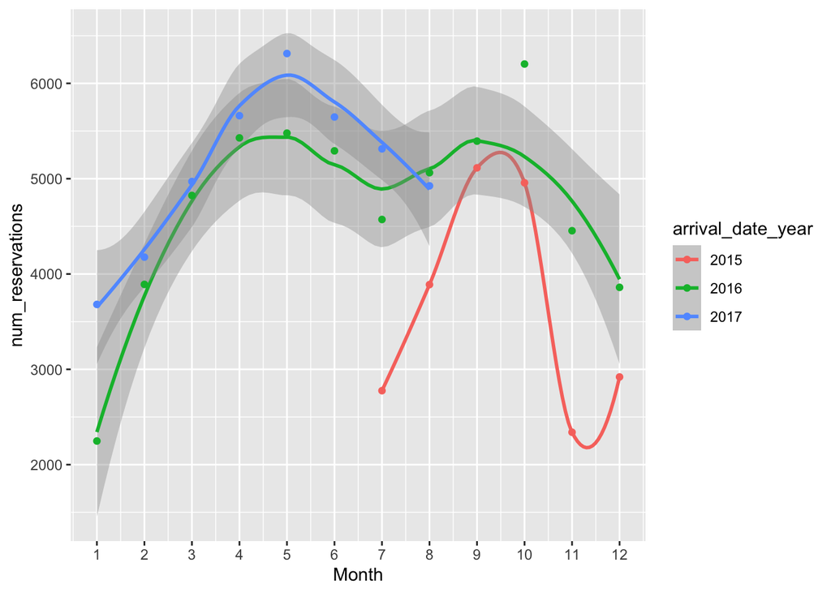

```r
#Number of reservations in each month, broken down by year
num_res_year_month = hotel_data %>%
  group_by(arrival_date_year, month_num) %>%
  summarize(num_reservations = n())

ggplot(num_res_year_month, aes(x = month_num, y = num_reservations)) +
  geom_smooth(aes(color = arrival_date_year)) +
  geom_point(aes(color = arrival_date_year)) +
  scale_x_continuous(name="Month", breaks = seq(0,12, 1))
```

**Percentage of reservations canceled broken down by year and month**

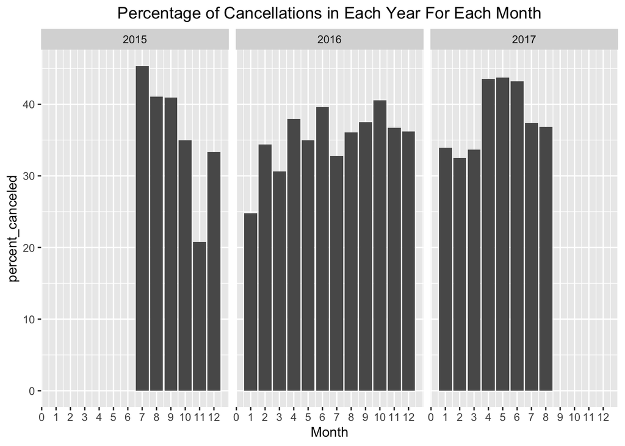

```r
#filtering data to show how many cancellations in each year and month
test = num_cancellations_by_year_month %>%
  filter(is_canceled == 1) #selecting all the

percent_reservations_canceled = merge(num_res_year_month, test, by = c("arrival_date_year", "month_num")) %>%
  mutate(percent_canceled = (num_cancellations/num_reservations)*100) %>%
  select(arrival_date_year, month_num, percent_canceled)

ggplot(percent_reservations_canceled, aes(x = month_num, y = percent_canceled)) +
  geom_bar(stat = "identity") +
  scale_x_continuous(name="Month", breaks = seq(0,12, 1)) +
  facet_wrap(~arrival_date_year) +
  ggtitle("Percentage of Cancellations in Each Year For Each Month") +
  theme(plot.title = element_text(hjust = 0.5))
```

**Length of Stay**

After calculating the total length of stay, we show the total length of stay with basic descriptive statistics and a histogram. We can see that the mean and median are 3.428 and 3 days respectively.

```r
#Total length of stay
hotel_data$total_stay = hotel_data$stays_in_week_nights + hotel_data$stays_in_weekend_nights

summary(hotel_data$total_stay)
```

```
##    Min. 1st Qu.  Median    Mean 3rd Qu.    Max.
##   0.000   2.000   3.000   3.428   4.000  69.000
```

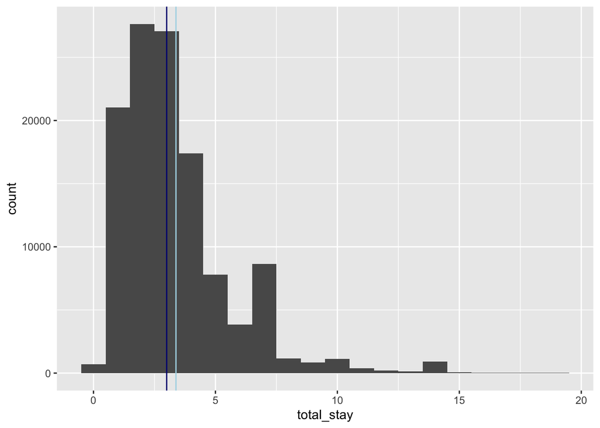

```r
filter(hotel_data, total_stay < 20) %>%
ggplot(aes(x = total_stay)) +
  geom_histogram(binwidth = 1) +
  geom_vline(aes(xintercept = mean(total_stay)), color = "lightblue") +
  geom_vline(aes(xintercept = median(total_stay)), color = "navy")
```

**Lead Time and Cancellations**

```r
#How many cancelations per days of lead time
group_by(hotel_data, is_canceled, lead_time) %>%
  summarize(count = n())
```

```
## # A tibble: 887 x 3
## # Groups:   is_canceled [2]
##    is_canceled lead_time count
##          <int>     <int> <int>
##  1           0         0  5915
##  2           0         1  3139
##  3           0         2  1856
##  4           0         3  1634
##  5           0         4  1539
##  6           0         5  1359
##  7           0         6  1243
##  8           0         7  1159
##  9           0         8   915
## 10           0         9   773
## # … with 877 more rows
```

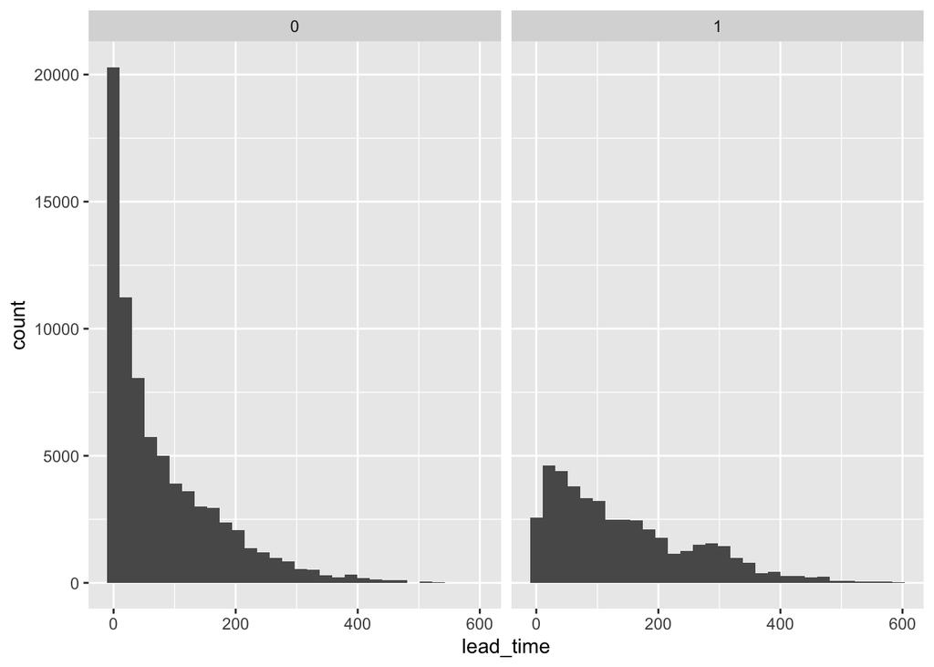

```r
#Histograms of lead time by whether or not there were cancellations.
filter(hotel_data, lead_time < 600) %>%
ggplot(aes(x = lead_time)) +
  geom_histogram() +
  facet_wrap(~is_canceled)
```

**Cancellations and Market Segment**

```r
#Number of reservations by market segment
a = group_by(hotel_data, market_segment) %>%
  summarize(total_reservations = n())

#Number of uncanceled reservations by market segment
b = filter(hotel_data, is_canceled == 0)  %>%
group_by(market_segment) %>%
  summarize(number_uncanceled_reservations = n())

#Number of canceled reservations by market segment
c = filter(hotel_data, is_canceled == 1)  %>%
group_by(market_segment) %>%
  summarize(number_canceled_reservations = n())

reservations = merge(a, b, by="market_segment") %>%
  merge(c, by = "market_segment") %>%
  mutate(percent_canceled = number_canceled_reservations/total_reservations) %>%
  select(market_segment, percent_canceled, total_reservations, number_uncanceled_reservations, number_canceled_reservations) %>%
  rename(
    number_uncanceled = number_uncanceled_reservations,
    number_canceled = number_canceled_reservations
  )

reservations
```

```
##   market_segment percent_canceled total_reservations number_uncanceled
## 1       Aviation        0.2194093                237               185
## 2  Complementary        0.1305518                743               646
## 3      Corporate        0.1873466               5295              4303
## 4         Direct        0.1534190              12606             10672
## 5         Groups        0.6106204              19811              7714
## 6  Offline TA/TO        0.3431603              24219             15908
## 7      Online TA        0.3672114              56477             35738
##   number_canceled
## 1              52
## 2              97
## 3             992
## 4            1934
## 5           12097
## 6            8311
## 7           20739
```

**Average Daily Rate and Number of Adults**

We can see that as the number of adults in a booking increases through reservations of four adults, the average daily rate also increases. There are reservations with more than 4 people, but there are not enough to generate boxplots.

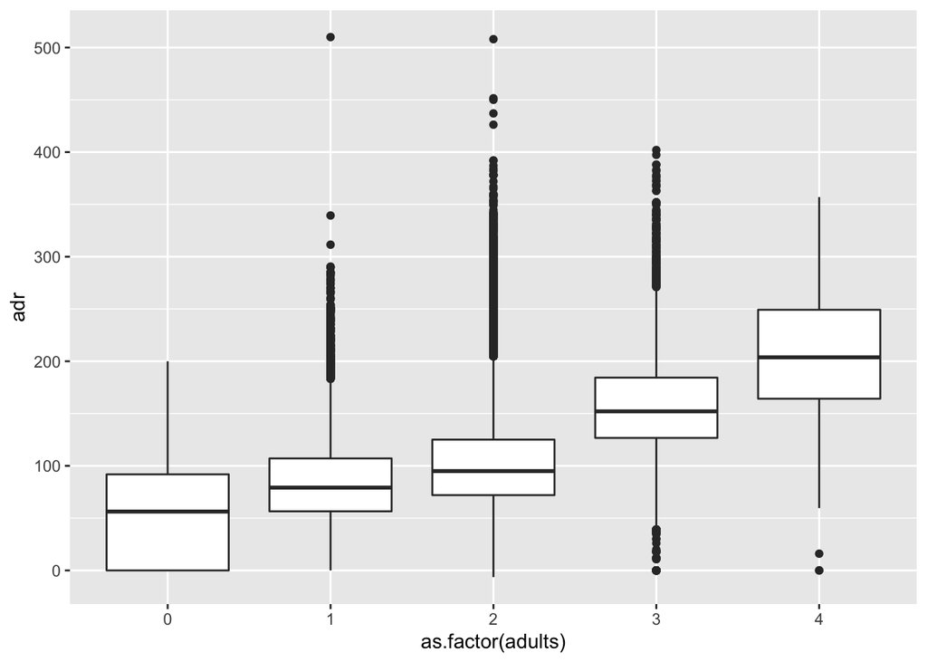

```r
filter(hotel_data, adr < 1000, adults < 5) %>%
ggplot(aes(x = as.factor(adults), y = adr)) +
  geom_boxplot()
```

**Average Daily Rate and Month**

```r
#Average Daily Rate by Month
group_by(hotel_data, month_num) %>%
  summarize(avg_adr = mean(adr, na.rm = TRUE))
```

```
## # A tibble: 12 x 2
##    month_num avg_adr
##        <int>   <dbl>
##  1         1    70.4
##  2         2    73.6
##  3         3    80.7
##  4         4   100.
##  5         5   109.
##  6         6   117.
##  7         7   127.
##  8         8   140.
##  9         9   105.
## 10        10    87.9
## 11        11    73.8
## 12        12    81.1
```

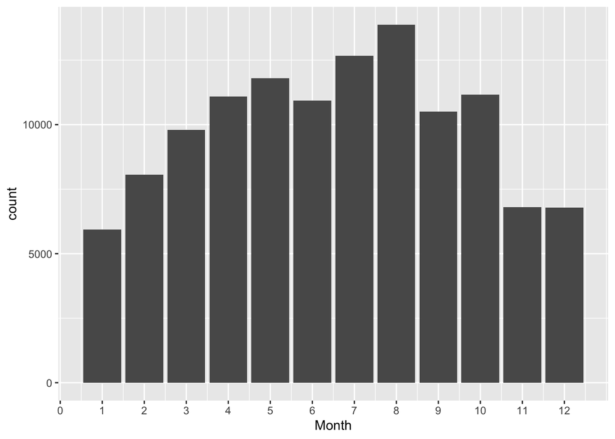

```r
ggplot(data = hotel_data, aes(x = month_num)) +
  geom_bar() +
  scale_x_continuous(name="Month", breaks = seq(0,12, 1))
```